# Assignment 1

Ashleigh Bynum

August 23, 2017

### Problem 1a - Time Plot of Spot Crude Oil Prices

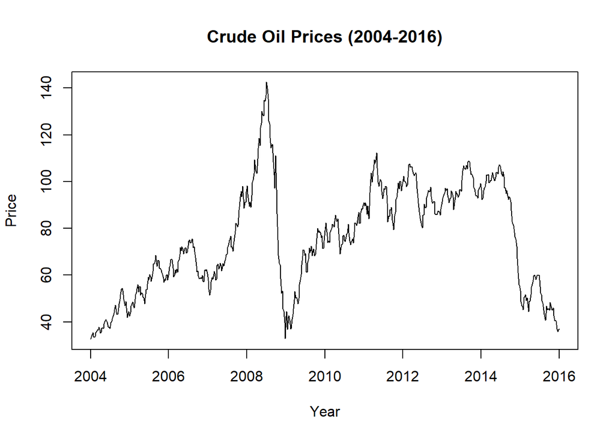

### Problem 1b - Percentage Change of Spot Crude Oil Prices

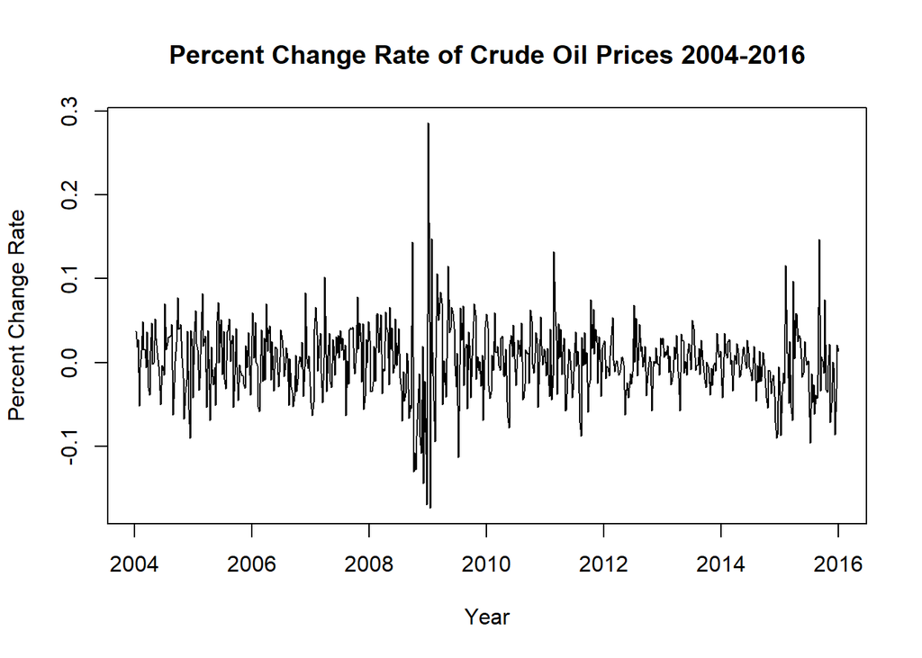

### Problem 1c - Histogram of Percent Change Rate

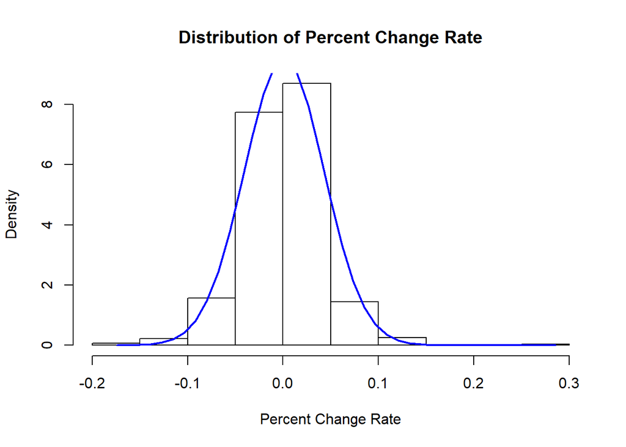

The distribution of percent change rates is slightly skewed to the right. What this translates to is that between 2004 and 2016, we saw a greater distribution of positive percent change rates than we did negative percent change rates. This distribution is almost close to a normal distribution however, as there are only a few more distribution ranges that are positive than there are negative.

### Problem 1d - Log Value of Spot Prices

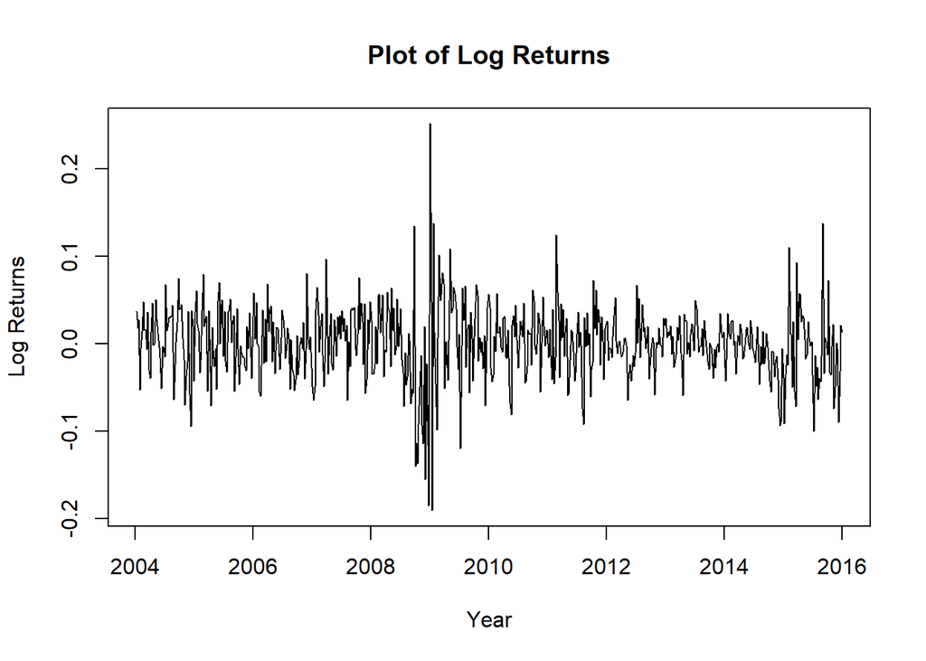

### Problem 2A - Plotting

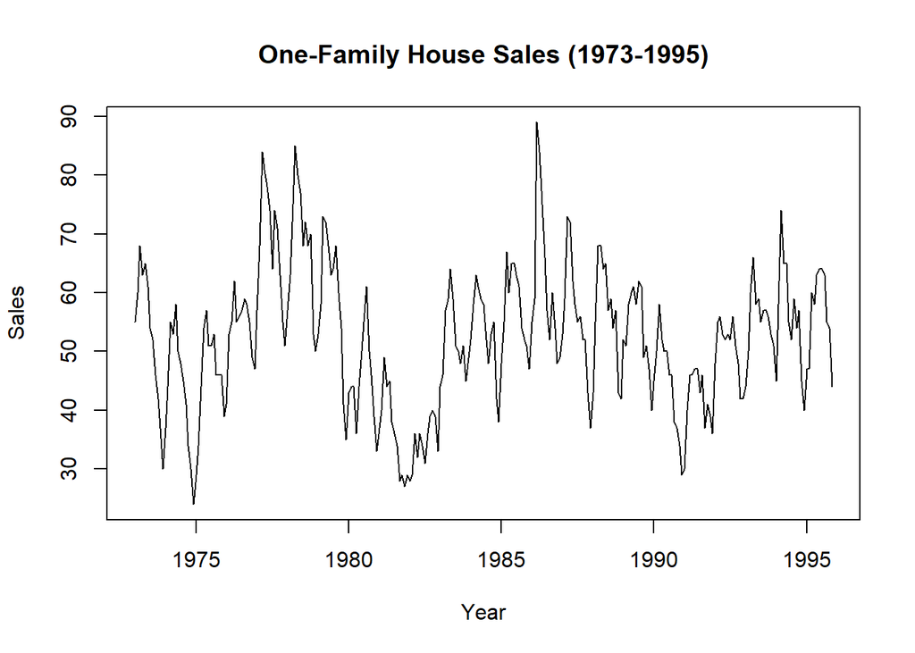

There are instances of large drops in sales that will need to be researched further in order to understand the larger picture. For example, in 1974 and 75 there are big declines in sales. What happened in those years that might help to answer why? Seasonality doesn’t seem to hold consistent, so we will need to introduce more methods in order to understand clearer.

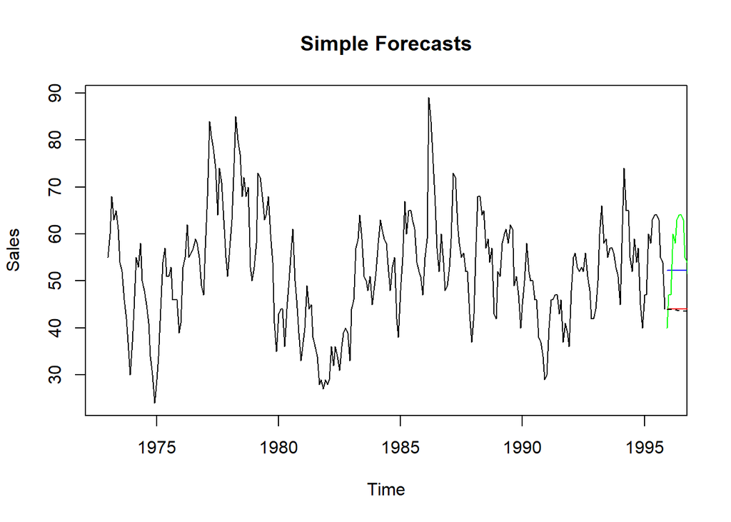

The test data accounting for the last two year does not make sense, because the last two years capture a different trend than previous years. The general trend that followed was a spike at the beginning of the year followed by a downward trend until the end of the year. The last year had an opposite effect….a lag in sales until the end of the year where a spike in sales was experienced. The forecast predicts the next year will follow the same trend, when it reality this is the exception.

### Problem 2c - Benchmark Method

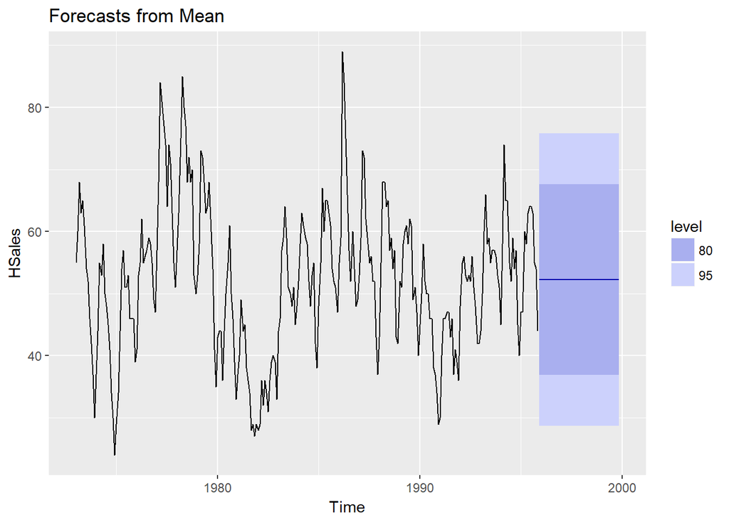

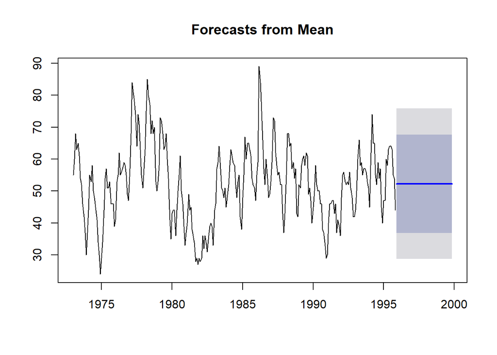

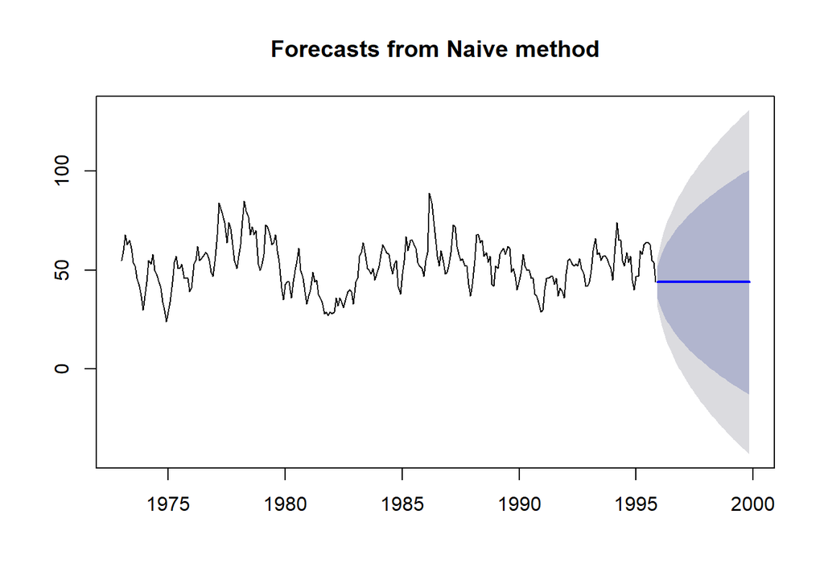

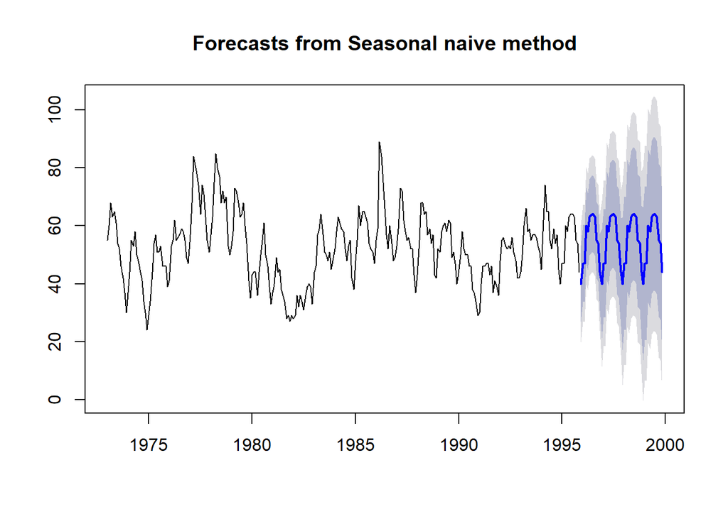

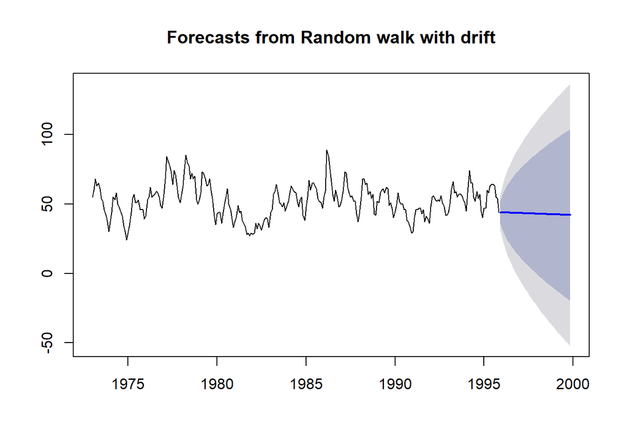

Based on the results, The criteria of seasonality and cylical is best captured using the seasonal method. The other methods fail to capture seasonality and have a general idea of what the forecast might be.

### Problem 3A - Lubridate

##### Exercise 1

```r
start_date = dmy("23012017")
```

##### Exercise 2

```r
#Get Today's Date
today()
```

```
## [1] "2017-08-29"
```

##### Exercise 3

```r
year(start_date)
```

```
## [1] 2017
```

##### Exercise 4

```r
month(start_date)
```

```
## [1] 1
```

##### Exercise 5

```r
day(start_date)
```

```
## [1] 23
```

##### Exercise 6

```r
month(start_date) = 2
```

##### Exercise 7

```r
start_date + days(6)
```

```
## [1] "2017-03-01"
```

##### Exercise 8

```r
start_date - months(3)
```

```
## [1] "2016-11-23"
```

##### Exercise 9

```r
concatenated_dates = dmy(c("31.12.2015", "01.01.2016", "15.02.2016"))

concatenated_dates
```

```
## [1] "2015-12-31" "2016-01-01" "2016-02-15"
```

##### Exercise 10

```r
start_date + c(1:10) * days(1)
```

```
##  [1] "2017-02-24" "2017-02-25" "2017-02-26" "2017-02-27" "2017-02-28"
##  [6] "2017-03-01" "2017-03-02" "2017-03-03" "2017-03-04" "2017-03-05"
```